# MTHM503 Assignment

#### K. Donkers - 700063874

## A. Traffic Accidents

### 1. Download and import traffic accidents data

Import the Pandas package

```python
import pandas as pd
```

Load the accidents2019.csv file into a Pandas dataframe

```python
fname = 'accidents2019.csv'
accidents = pd.read_csv(fname, low_memory=False)
```

Select the first two rows

```python
accidents.iloc[0:2]
```

|  | Accident_Index | Location_Easting_OSGR | Location_Northing_OSGR | Longitude | Latitude | Police_Force | Accident_Severity | Number_of_Vehicles | Number_of_Casualties | Date | ... | Pedestrian_Crossing-Human_Control | Pedestrian_Crossing-Physical_Facilities | Light_Conditions | Weather_Conditions | Road_Surface_Conditions | Special_Conditions_at_Site | Carriageway_Hazards | Urban_or_Rural_Area | Did_Police_Officer_Attend_Scene_of_Accident | LSOA_of_Accident_Location |
| --- | --- | --- | --- | --- | --- | --- | --- | --- | --- | --- | --- | --- | --- | --- | --- | --- | --- | --- | --- | --- | --- |
| 0 | 2019010128300 | 528218.0 | 180407.0 | -0.153842 | 51.508057 | 1 | 3 | 2 | 3 | 18/02/2019 | ... | 0 | 5 | 1 | 1 | 1 | 0 | 0 | 1 | 3 | E01004762 |
| 1 | 2019010152270 | 530219.0 | 172463.0 | -0.127949 | 51.436208 | 1 | 3 | 2 | 1 | 15/01/2019 | ... | -1 | -1 | 4 | 1 | 1 | 0 | 0 | 1 | 3 | E01003117 |

2 rows × 32 columns

### 2. General

#### (i) How many accidents happened in 2019?

Convert `Date` column to contain datetime objects

```python
accidents['Date'] = pd.to_datetime(accidents['Date'])
```

We can now filter the dateframe based on the year of the datetime objects in 'Date'

```python
len(accidents.loc[accidents['Date'].dt.year==2019])
```

```
117536
```

Therefore the number of accidents that happened in 2019 is 117536

Let's compare that to the total number of accidents

```python
len(accidents)
```

```
117536
```

So, all of the accidents happened in 2019

#### (ii) What are the column names in the data frame?

A `DataFrame` has a `columns` attribute, which can be better displayed when converted to a `list`

```python
list(accidents.columns)
```

```
['Accident_Index',
 'Location_Easting_OSGR',
 'Location_Northing_OSGR',
 'Longitude',
 'Latitude',
 'Police_Force',
 'Accident_Severity',
 'Number_of_Vehicles',
 'Number_of_Casualties',
 'Date',
 'Day_of_Week',
 'Time',
 'Local_Authority_(District)',
 'Local_Authority_(Highway)',
 '1st_Road_Class',
 '1st_Road_Number',
 'Road_Type',
 'Speed_limit',
 'Junction_Detail',
 'Junction_Control',
 '2nd_Road_Class',
 '2nd_Road_Number',
 'Pedestrian_Crossing-Human_Control',
 'Pedestrian_Crossing-Physical_Facilities',
 'Light_Conditions',
 'Weather_Conditions',
 'Road_Surface_Conditions',
 'Special_Conditions_at_Site',
 'Carriageway_Hazards',
 'Urban_or_Rural_Area',
 'Did_Police_Officer_Attend_Scene_of_Accident',
 'LSOA_of_Accident_Location']
```

#### (iii) Report the date (day/month/year) and coordinates (longitude and latitude) of the accident in the 100th row of the data frame.

Since Python indexes from 0, the 100th row corresponds to an index of 99

```python
i_100 = 99
```

The `Date` column now consists of `datetime` objects which we can format into strings however we want using the `strftime` method

```python
accidents['Date'].iloc[i_100].strftime('%d/%m/%Y')
```

```
'01/03/2019'
```

We can pull the 100th entries from the `Longitude` and `Latitude` columns too

```python
accidents['Longitude'].iloc[i_100]
```

```
-0.264403
```

```python
accidents['Latitude'].iloc[i_100]
```

```
51.498486
```

#### (iv) Do any of str columns contain information about the type of vehicles involved in the accident?

First let's find which columns are `str` datatypes. We can do this using the method `select_dtypes`. This method doesn't recognise the `str` datatype, so instead we use `object`.

```python
accidents.select_dtypes(include=object).head()
```

|  | Accident_Index | Time | Local_Authority_(Highway) | LSOA_of_Accident_Location |
| --- | --- | --- | --- | --- |
| 0 | 2019010128300 | 17:50 | E09000033 | E01004762 |
| 1 | 2019010152270 | 21:45 | E09000022 | E01003117 |
| 2 | 2019010155191 | 01:50 | E09000007 | E01000943 |
| 3 | 2019010155192 | 01:20 | E09000007 | E01000973 |
| 4 | 2019010155194 | 00:40 | E09000005 | E01000546 |

These four columns that are of datatype `object` (`Accident_Index`, `Time`, `Local_Authority_(Highway)`, `LSOA_of_Accident_Location`) don't appear to contain any information about the types of vehicles involved.

Perhaps there is a column containing relevant data which has a mislabelled datatype. To find out let's list all the columns with datatypes other than `object` and `'number'`

```python
accidents.select_dtypes(exclude=[object, 'number']).head()
```

|  | Date |
| --- | --- |
| 0 | 2019-02-18 |
| 1 | 2019-01-15 |
| 2 | 2019-01-01 |
| 3 | 2019-01-01 |
| 4 | 2019-01-01 |

Given that only the `Date` column is neither `object` or `'number'` datatype, we can be confident that we haven't missed a column that contains information about the type of vehicle involved in the accident.

### 3. Casualties

#### (i) Calculate the total number of casualties

We can find the total number of casualties in the `DataFrame` using the `sum` method on the `Number_of_Casualties` column

```python
accidents['Number_of_Casualties'].sum()
```

```
153158
```

#### (ii) What is the difference in the number of casualties between Lower Layer Super Output area (LSOA) E01032739 (City of London 001F) and E01033708 (Hackney 027G)?

First we can subset `accidents` to the two LSOA areas of interest

```python
city = accidents.loc[accidents['LSOA_of_Accident_Location']=='E01032739']
hackney = accidents.loc[accidents['LSOA_of_Accident_Location']=='E01033708']
```

Then we can sum the number of casualties in each location

```python
city_casualties = city['Number_of_Casualties'].sum()
hackney_casualties = hackney['Number_of_Casualties'].sum()
```

Then we simply subtract the total number of casualties in each location from each other to get the difference

```python
print(f"City of London casualties = {city_casualties}")
print(f"Hackney casualties        =  {hackney_casualties}")
print(f"                            ---")
print(f"Difference                = {city_casualties-hackney_casualties}")
```

```
City of London casualties = 212
Hackney casualties        =  76
                            ---
Difference                = 136
```

#### (iii) What LSOA saw the highest total number of casualties in 2019?

First we should group `accidents` by `LSOA_of_Accident_Location`, aggregating with a sum of the columns. We need the `sum` function from Numpy in order to do the aggregation.

```python
import numpy as np
```

```python
lsoas = accidents.groupby('LSOA_of_Accident_Location').aggregate(np.sum)
lsoas.head()
```

| LSOA_of_Accident_Location | Location_Easting_OSGR | Location_Northing_OSGR | Longitude | Latitude | Police_Force | Accident_Severity | Number_of_Vehicles | Number_of_Casualties | Day_of_Week | Local_Authority_(District) | ... | 2nd_Road_Number | Pedestrian_Crossing-Human_Control | Pedestrian_Crossing-Physical_Facilities | Light_Conditions | Weather_Conditions | Road_Surface_Conditions | Special_Conditions_at_Site | Carriageway_Hazards | Urban_or_Rural_Area | Did_Police_Officer_Attend_Scene_of_Accident |
| --- | --- | --- | --- | --- | --- | --- | --- | --- | --- | --- | --- | --- | --- | --- | --- | --- | --- | --- | --- | --- | --- |
| E01000001 | 6917744.0 | 2362078.0 | -1.260497 | 669.743879 | 624 | 37 | 22 | 14 | 54 | 7410 | ... | 2526 | 0 | 14 | 34 | 16 | 16 | 0 | 0 | 13 | 18 |
| E01000002 | 4259403.0 | 1452691.0 | -0.742467 | 412.141487 | 337 | 22 | 15 | 8 | 34 | 3993 | ... | 0 | -1 | 8 | 17 | 16 | 6 | -1 | -1 | 8 | 12 |
| E01000003 | 532101.0 | 182029.0 | -0.097315 | 51.521739 | 48 | 3 | 1 | 1 | 5 | 570 | ... | 0 | 0 | 8 | 4 | 1 | 1 | 0 | 0 | 1 | 2 |
| E01000005 | 4269186.0 | 1448842.0 | -0.603015 | 412.104596 | 290 | 22 | 16 | 8 | 24 | 3430 | ... | 3642 | -1 | 18 | 11 | 8 | 8 | 0 | 0 | 8 | 11 |
| E01000007 | 4898603.0 | 1659656.0 | 0.712947 | 463.861078 | 9 | 25 | 16 | 17 | 45 | 144 | ... | 372 | -3 | 15 | 15 | 19 | 12 | -1 | 0 | 9 | 19 |

5 rows × 27 columns

Now we can identify the LSAO with the maximum total `Number_of_Casualties` using the `max` method

```python
lsoas.loc[lsoas['Number_of_Casualties']==lsoas['Number_of_Casualties'].max()]
```

| LSOA_of_Accident_Location | Location_Easting_OSGR | Location_Northing_OSGR | Longitude | Latitude | Police_Force | Accident_Severity | Number_of_Vehicles | Number_of_Casualties | Day_of_Week | Local_Authority_(District) | ... | 2nd_Road_Number | Pedestrian_Crossing-Human_Control | Pedestrian_Crossing-Physical_Facilities | Light_Conditions | Weather_Conditions | Road_Surface_Conditions | Special_Conditions_at_Site | Carriageway_Hazards | Urban_or_Rural_Area | Did_Police_Officer_Attend_Scene_of_Accident |
| --- | --- | --- | --- | --- | --- | --- | --- | --- | --- | --- | --- | --- | --- | --- | --- | --- | --- | --- | --- | --- | --- |
| E01032739 | 103358156.0 | 35141904.0 | -17.062966 | 9993.643623 | 9312 | 536 | 300 | 212 | 792 | 110580 | ... | 33248 | 0 | 633 | 392 | 219 | 219 | 12 | 0 | 196 | 256 |

1 rows × 27 columns

Therefore the City of London (E01032739) is the LSOA with the highest total casualties in 2019

### 4. Police officer attendance

#### (i) What are the possible values that occur in the column Did_Police_Officer_Attend_Scene_of_Accident, and how often does each value occur?

The `unique` method returns a list of all the unique values in a `Series`. We can use this to find all the unique values in `Did_Police_Officer_Attend_Scene_of_Accident`

```python
accidents['Did_Police_Officer_Attend_Scene_of_Accident'].unique()
```

```
array([3, 1, 2])
```

```python
accidents['Did_Police_Officer_Attend_Scene_of_Accident'].value_counts(dropna=False)
```

```
1    81309
2    26285
3     9942
Name: Did_Police_Officer_Attend_Scene_of_Accident, dtype: int64
```

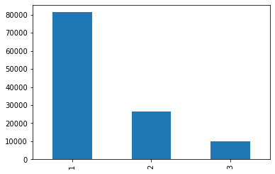

```python
accidents['Did_Police_Officer_Attend_Scene_of_Accident'].astype(str).value_counts().plot(kind='bar')
```

#### (ii) The value Did_Police_Officer_Attend_Scene_of_Accident = 1 indicates that a police officer attended the accident. What do the other value(s) in that column mean? (Consult the data website to answer this question.)

The [data website](https://data.gov.uk/dataset/cb7ae6f0-4be6-4935-9277-47e5ce24a11f/road-safety-data) has a link to a [lookup table](http://data.dft.gov.uk/road-accidents-safety-data/variable%20lookup.xls) for the data variables (provided as an Excel spreadsheet).

This lookup table states that the "Police Officer Attendance" codes stand for the following:

| Code | Value |
| --- | --- |
| 1 | Yes |
| 2 | No |
| 3 | No - accident was reported using a self completion form (self rep only) |

#### (iii) What fraction of accidents was attended by a police officer?

Here we simply need to divide the total number of `Did_Police_Officer_Attend_Scene_of_Accident` which are equal to 1 by the total number of rows in `accidents`

```python
sum(accidents['Did_Police_Officer_Attend_Scene_of_Accident']==1)/len(accidents)
```

```
0.6917795398856521
```

#### (iv) What fraction of those accidents that happened on a weekday was attended by a police officer? How does this number compare to the corresponding fraction for accidents on weekends?

First we need to assign each accident a boolean to indicate whether it happened on a weekday.  
To do this we pull out the day name from the `Date` column (storead as `Day_of_Week`) then categorise each day into whether it is a `Weekday`

```python
accidents['Day_of_Week'] = accidents['Date'].dt.strftime('%a')
accidents['Weekday'] = accidents['Day_of_Week'].isin(['Mon', 'Tue', 'Wed', 'Thu', 'Fri'])
accidents['Weekday'].head()
```

```
0    True
1    True
2    True
3    True
4    True
Name: Weekday, dtype: bool
```

We can now pull out all the accidents that happened on a weekday, pick out the ones where the police attended and calculate this number as a total of accidents on a weekday.

```python
weekday = accidents[accidents['Weekday']==True]

len(weekday[weekday['Did_Police_Officer_Attend_Scene_of_Accident']==1])/len(weekday)
```

```
0.6871030579665042
```

We can do the same for accidents that happened on a weekend

```python
weekend = accidents[accidents['Weekday']==False]
len(weekend[weekend['Did_Police_Officer_Attend_Scene_of_Accident']==1])/len(weekend)
```

```
0.7049611748269924
```

From this we can see that police attend a slightly higher fraction of accidents at the weekend compared to weekdays

### 5. Visualisation

#### (i) Visualise the locations of all accidents by a scatter plot of Latitude vs Longitude. Annotate the axes, add a plot title, and increase the figure size to 10in by 10in.

For plotting we are going to need Matplotlib's `pyplot`. To aid geographical plotting we are going to need coordinate reference system (CRS) objects from Cartopy

```python
import matplotlib.pyplot as plt
import cartopy.crs as ccrs
```

Let's pull out the `Longitude` and `Latitude` values from `accidents` and set them as variables `x` and `y`

```python
x = accidents['Longitude']
y = accidents['Latitude']
```

Next let's construct a scatter plot of the lat-lon pairs. To aid visualisation we can include coastlines and gridlines, which Cartopy allows us to add.  
We are going to reproject the data into an [Orthographic](https://scitools.org.uk/cartopy/docs/latest/crs/projections.html#orthographic) projection to give the perspective of viewing it from space.

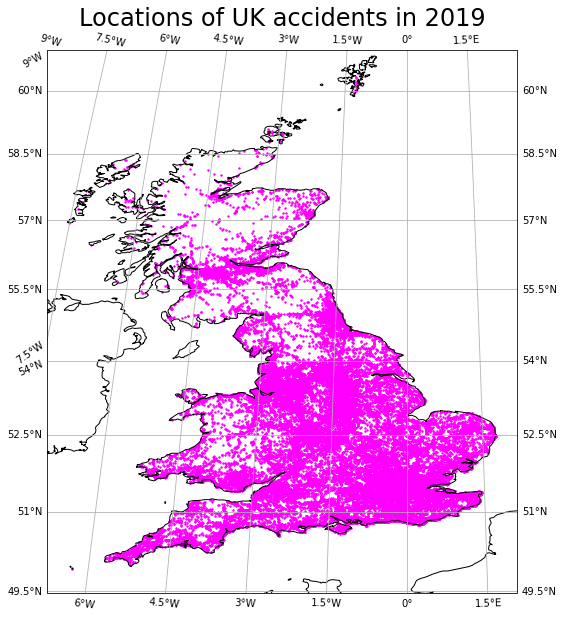

```python
# Create figure and axes objects, specifying the final projection of the plot
fig = plt.figure(figsize=(10,10))
ax = plt.axes(projection=ccrs.Orthographic())

# Create a scatter plot of the data with small magenta circles.
# PlateCarree is the default projection for simple lat-ln values
ax.scatter(x, y, c='magenta', s=2, transform=ccrs.PlateCarree())

# Add coastlines and gridlines (with labels)
ax.coastlines()
ax.gridlines(draw_labels=True)

# Add a title
ax.set_title('Locations of UK accidents in 2019', size=24)

plt.show()
```

#### (ii) Create a similar scatter plot as in the previous question 5(i). but zoom in on a 2 by 2 degree area that includes Exeter/Devon, and choose a different color for accidents that happened in a rural area and in an urban area. Include a red marker that indicates the coordinates of Exeter/Devon (as per wikipedia).

According to the data lookup table, `Urban_or_Rural_Area` can have one of the three values:

| code | label |
| --- | --- |
| 1 | Urban |
| 2 | Rural |
| 3 | Unallocated |

We can pull out lat-lon pairs for each of these categories

```python
urban = accidents[accidents['Urban_or_Rural_Area']==1][['Latitude', 'Longitude']]
rural = accidents[accidents['Urban_or_Rural_Area']==2][['Latitude', 'Longitude']]
unalloc = accidents[accidents['Urban_or_Rural_Area']==3][['Latitude', 'Longitude']]
```

Now we can create a scatter plot with these three groups of lat-lon pairs, focussed on Devon and a marker on Exeter

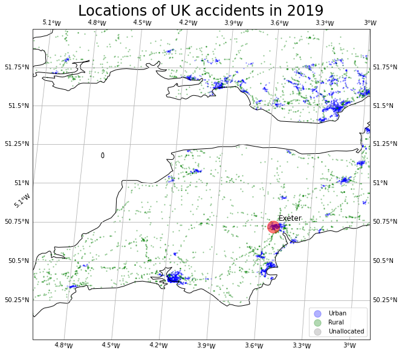

```python
# Create figure and axes objects, specifying the final projection of the plot
fig = plt.figure(figsize=(10,10))
ax = plt.axes(projection=ccrs.Orthographic())

# Add marker for Exeter
ax.plot(-3.533333, 50.716667, marker='o', markersize=20, color='r', alpha=0.5, transform=ccrs.PlateCarree())
ax.text(-3.503333, 50.756667, 'Exeter', size=12, transform=ccrs.PlateCarree())

# Create a scatter plots for each category of data
ax.scatter(urban['Longitude'], urban['Latitude'], c='b', s=2, alpha=0.3, transform=ccrs.PlateCarree(), label='Urban')
ax.scatter(rural['Longitude'], rural['Latitude'], c='g', s=2, alpha=0.3, transform=ccrs.PlateCarree(), label='Rural')
ax.scatter(unalloc['Longitude'], unalloc['Latitude'], c='grey', s=2, alpha=0.3, transform=ccrs.PlateCarree(), label='Unallocated')

# Set extent to 2x2 degree area around Devon
ax.set_extent([-5, -3, 50, 52])

# Add coastlines and gridlines (with labels)
ax.coastlines()
ax.gridlines(draw_labels=True)

# Add a title and legend
ax.set_title('Locations of UK accidents in 2019', size=24)
ax.legend(loc='lower right', markerscale=8)

plt.show()
```

#### (iii) Are accidents at higher speed limits more likely to be fatal than at lower speed limits? Answer the question with an appropriate data visualisation and a short written summary.

To answer this question we are going to need to create three plots:

1. Number of accidents at each speed limit
2. Number of fatal accidents at each speed limit
3. Proportion of accidents which are fatal at each speed limit

We do not have information about the speed at which the accidents occurred, but we do know the speed limit of the roads on which they occured. Therefre for this investigation we want to use `Accident_Severity`, `Speed_limit` and the total number of accidents from the DataFrame `accidents`.

From the data lookup table we find that the values of `Accident_Severity` represent the following categories:

| code | label |
| --- | --- |
| 1 | Fatal |
| 2 | Serious |
| 3 | Slight |

Therefore to understand the number of fatalities at each speed limit we must select the `Accident_Severity` values equal to `1`

Let's create a dataframe containing the total number of accidents, fatal accidents and proportion of accidents which are fatal

```python
# First we use a groupby operation to count the number of accidents in each speed limit (any column will do)
speeds = accidents.groupby('Speed_limit')[['Number_of_Casualties']].count()
speeds.rename(columns={'Number_of_Casualties': 'Number_of_accidents'}, inplace=True)

# We can then count the number of fatal accidents in each speeds limit
fatal = accidents[accidents['Accident_Severity']==1]
speeds['Number_of_fatalities'] = fatal.groupby(['Speed_limit'])['Accident_Severity'].count()

# Finally let's add a column which is the proportion of accidents that are fatal at each speed limit
speeds['Fatal_proportion'] = speeds['Number_of_fatalities']/speeds['Number_of_accidents']

speeds
```

| Speed_limit | Number_of_accidents | Number_of_fatalities | Fatal_proportion |
| --- | --- | --- | --- |
| -1 | 80 | NaN | NaN |
| 20 | 11747 | 55.0 | 0.004682 |
| 30 | 69305 | 544.0 | 0.007849 |
| 40 | 10021 | 185.0 | 0.018461 |
| 50 | 4716 | 118.0 | 0.025021 |
| 60 | 14514 | 551.0 | 0.037963 |
| 70 | 7153 | 205.0 | 0.028659 |

An unknown speedlimit of `-1` is of little use to us, so let's drop it

```python
speeds.drop(-1, inplace=True)
speeds
```

| Speed_limit | Number_of_accidents | Number_of_fatalities | Fatal_proportion |
| --- | --- | --- | --- |
| 20 | 11747 | 55.0 | 0.004682 |
| 30 | 69305 | 544.0 | 0.007849 |
| 40 | 10021 | 185.0 | 0.018461 |
| 50 | 4716 | 118.0 | 0.025021 |
| 60 | 14514 | 551.0 | 0.037963 |
| 70 | 7153 | 205.0 | 0.028659 |

We can now plot each of the columns in `speeds` to understand the relationship between accidents and speed limits

##### Number of accidents vs speed limit

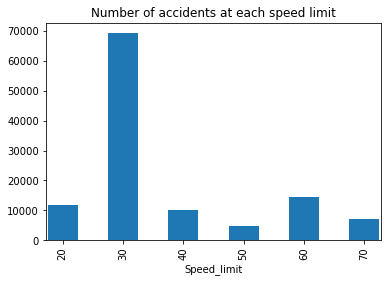

```python
speeds['Number_of_accidents'].plot(kind='bar', width=5)
plt.gca().set_title('Number of accidents at each speed limit')
plt.show()
```

##### Number of fatal accidents vs speed limit

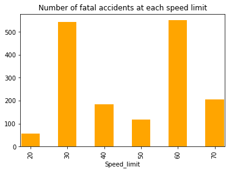

```python
speeds['Number_of_fatalities'].plot(kind='bar', color='orange', width=5)
plt.gca().set_title('Number of fatal accidents at each speed limit')
plt.show()
```

This plot shows us that the total number of fatalities at 30 mph and 60 mph speed limits in 2019 are about equal. This is starting to support the hypothesis that accidents that occur at higher speeds are more likely to be fatal.

##### Proportion of accidents vs speed limit

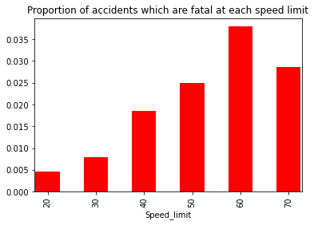

```python
speeds['Fatal_proportion'].plot(kind='bar', color='red', width=5)
plt.gca().set_title('Proportion of accidents which are fatal at each speed limit')
plt.show()
```

This plot clearly shows a positive correlation between the speed limit of the road on which the accident happened and the proportion of those accidents which were fatal. The exception to this is a (relative) decrease in fatality in 70 mph speed limit zones compared to 60 mph speed limit zones. This might be explained by the fact that roads with 70 mph speed limits tend to be wide, multi-lane, straight roads (motorways, dual carriageways) which gives drivers more opportunity to respond to hazards and thus reduce the fatality of possible accidents. Comparatively, 60 mph speed limits cover a wide range of road types, including winding country roads with poor visibility, which give motorists less chance to avoild hazards.

These plots support the hypothesis that accidents at higher speeds tend to be more fatal. This would make sense given that accidents occuring at higher speed are more likely to result in higher impact forces and thus more serious injury. As noted above, the reduced fatality of 70 mph speed limits might be explained by the types of roads that use this speed limit, rather than the relative safety of travelling at that speed.